# Risk Factor Analysis

## Outcome Variable

**Outcome Variable:** whz

## Predictor Variables

**Intervention Variable:** impsan

**Adjustment Set:**

unadjusted

## Stratifying Variables

The analysis was stratified on these variable(s):

- agecat
- studyid
- country

## Data Summary

| agecat | studyid | country | impsan | n_cell | n |
| --- | --- | --- | --- | --- | --- |
| Birth | COHORTS | GUATEMALA | 1 | 43 | 449 |
| Birth | COHORTS | GUATEMALA | 0 | 406 | 449 |
| Birth | COHORTS | INDIA | 1 | 1685 | 4461 |
| Birth | COHORTS | INDIA | 0 | 2776 | 4461 |
| Birth | COHORTS | PHILIPPINES | 1 | 177 | 1126 |
| Birth | COHORTS | PHILIPPINES | 0 | 949 | 1126 |
| Birth | CONTENT | PERU | 1 | 1 | 2 |
| Birth | CONTENT | PERU | 0 | 1 | 2 |
| Birth | JiVitA-3 | BANGLADESH | 1 | 12413 | 17991 |
| Birth | JiVitA-3 | BANGLADESH | 0 | 5578 | 17991 |
| Birth | JiVitA-4 | BANGLADESH | 1 | 1859 | 2394 |
| Birth | JiVitA-4 | BANGLADESH | 0 | 535 | 2394 |
| Birth | MAL-ED | BANGLADESH | 1 | 168 | 201 |
| Birth | MAL-ED | BANGLADESH | 0 | 33 | 201 |
| Birth | MAL-ED | BRAZIL | 1 | 56 | 57 |
| Birth | MAL-ED | BRAZIL | 0 | 1 | 57 |
| Birth | MAL-ED | INDIA | 1 | 14 | 39 |
| Birth | MAL-ED | INDIA | 0 | 25 | 39 |
| Birth | MAL-ED | NEPAL | 1 | 24 | 25 |
| Birth | MAL-ED | NEPAL | 0 | 1 | 25 |
| Birth | MAL-ED | PERU | 1 | 50 | 203 |
| Birth | MAL-ED | PERU | 0 | 153 | 203 |
| Birth | MAL-ED | SOUTH AFRICA | 1 | 0 | 94 |
| Birth | MAL-ED | SOUTH AFRICA | 0 | 94 | 94 |
| Birth | MAL-ED | TANZANIA, UNITED REPUBLIC OF | 1 | 0 | 110 |
| Birth | MAL-ED | TANZANIA, UNITED REPUBLIC OF | 0 | 110 | 110 |
| Birth | NIH-Birth | BANGLADESH | 1 | 222 | 575 |
| Birth | NIH-Birth | BANGLADESH | 0 | 353 | 575 |
| Birth | NIH-Crypto | BANGLADESH | 1 | 610 | 696 |
| Birth | NIH-Crypto | BANGLADESH | 0 | 86 | 696 |

[output cut: 70 more lines]

The following strata were considered:

- agecat: 24 months, studyid: COHORTS, country: GUATEMALA
- agecat: 24 months, studyid: COHORTS, country: INDIA
- agecat: 24 months, studyid: COHORTS, country: PHILIPPINES
- agecat: 24 months, studyid: CONTENT, country: PERU
- agecat: 24 months, studyid: JiVitA-3, country: BANGLADESH
- agecat: 24 months, studyid: JiVitA-4, country: BANGLADESH
- agecat: 24 months, studyid: LCNI-5, country: MALAWI
- agecat: 24 months, studyid: MAL-ED, country: BANGLADESH
- agecat: 24 months, studyid: MAL-ED, country: BRAZIL
- agecat: 24 months, studyid: MAL-ED, country: INDIA
- agecat: 24 months, studyid: MAL-ED, country: NEPAL
- agecat: 24 months, studyid: MAL-ED, country: PERU
- agecat: 24 months, studyid: MAL-ED, country: SOUTH AFRICA
- agecat: 24 months, studyid: MAL-ED, country: TANZANIA, UNITED REPUBLIC OF
- agecat: 24 months, studyid: NIH-Birth, country: BANGLADESH
- agecat: 24 months, studyid: NIH-Crypto, country: BANGLADESH
- agecat: 24 months, studyid: PROVIDE, country: BANGLADESH
- agecat: 6 months, studyid: COHORTS, country: GUATEMALA
- agecat: 6 months, studyid: COHORTS, country: INDIA
- agecat: 6 months, studyid: COHORTS, country: PHILIPPINES
- agecat: 6 months, studyid: CONTENT, country: PERU
- agecat: 6 months, studyid: JiVitA-3, country: BANGLADESH
- agecat: 6 months, studyid: JiVitA-4, country: BANGLADESH
- agecat: 6 months, studyid: LCNI-5, country: MALAWI
- agecat: 6 months, studyid: MAL-ED, country: BANGLADESH
- agecat: 6 months, studyid: MAL-ED, country: BRAZIL
- agecat: 6 months, studyid: MAL-ED, country: INDIA
- agecat: 6 months, studyid: MAL-ED, country: NEPAL
- agecat: 6 months, studyid: MAL-ED, country: PERU
- agecat: 6 months, studyid: MAL-ED, country: SOUTH AFRICA
- agecat: 6 months, studyid: MAL-ED, country: TANZANIA, UNITED REPUBLIC OF
- agecat: 6 months, studyid: NIH-Birth, country: BANGLADESH
- agecat: 6 months, studyid: NIH-Crypto, country: BANGLADESH
- agecat: 6 months, studyid: PROVIDE, country: BANGLADESH
- agecat: Birth, studyid: COHORTS, country: GUATEMALA
- agecat: Birth, studyid: COHORTS, country: INDIA
- agecat: Birth, studyid: COHORTS, country: PHILIPPINES
- agecat: Birth, studyid: CONTENT, country: PERU
- agecat: Birth, studyid: JiVitA-3, country: BANGLADESH
- agecat: Birth, studyid: JiVitA-4, country: BANGLADESH
- agecat: Birth, studyid: MAL-ED, country: BANGLADESH
- agecat: Birth, studyid: MAL-ED, country: BRAZIL
- agecat: Birth, studyid: MAL-ED, country: INDIA
- agecat: Birth, studyid: MAL-ED, country: NEPAL
- agecat: Birth, studyid: MAL-ED, country: PERU
- agecat: Birth, studyid: MAL-ED, country: SOUTH AFRICA
- agecat: Birth, studyid: MAL-ED, country: TANZANIA, UNITED REPUBLIC OF
- agecat: Birth, studyid: NIH-Birth, country: BANGLADESH
- agecat: Birth, studyid: NIH-Crypto, country: BANGLADESH
- agecat: Birth, studyid: PROVIDE, country: BANGLADESH

### Dropped Strata

Some strata were dropped due to rare outcomes:

- agecat: Birth, studyid: CONTENT, country: PERU
- agecat: Birth, studyid: MAL-ED, country: BRAZIL
- agecat: Birth, studyid: MAL-ED, country: NEPAL
- agecat: Birth, studyid: MAL-ED, country: SOUTH AFRICA
- agecat: Birth, studyid: MAL-ED, country: TANZANIA, UNITED REPUBLIC OF
- agecat: Birth, studyid: PROVIDE, country: BANGLADESH
- agecat: 6 months, studyid: LCNI-5, country: MALAWI
- agecat: 6 months, studyid: MAL-ED, country: BRAZIL
- agecat: 6 months, studyid: MAL-ED, country: NEPAL
- agecat: 6 months, studyid: MAL-ED, country: SOUTH AFRICA
- agecat: 6 months, studyid: MAL-ED, country: TANZANIA, UNITED REPUBLIC OF
- agecat: 6 months, studyid: PROVIDE, country: BANGLADESH
- agecat: 24 months, studyid: LCNI-5, country: MALAWI
- agecat: 24 months, studyid: MAL-ED, country: BRAZIL
- agecat: 24 months, studyid: MAL-ED, country: NEPAL
- agecat: 24 months, studyid: MAL-ED, country: SOUTH AFRICA
- agecat: 24 months, studyid: MAL-ED, country: TANZANIA, UNITED REPUBLIC OF
- agecat: 24 months, studyid: PROVIDE, country: BANGLADESH

## Methods Detail

We’re interested in the causal parameters $E[Y_a]$ for all values of $a \in \mathcal{A}$. These parameters represent the mean outcome if, possibly contrary to fact, we intervened to set all units to have $A=a$. Under the randomization and positivity assumptions, these are identified by the statistical parameters $\psi_a=E_W[E_{Y|A,W}(Y|A=a,W)]$. In addition, we’re interested in the mean of $Y$, $E[Y]$ under no intervention (the observed mean). We will estimate these parameters by using SuperLearner to fit the relevant likelihood factors – $E_{Y|A,W}(Y|A=a,W)$ and $p(A=a|W)$, and then updating our likelihood fit using a joint TMLE.

For unadjusted analyses ($W=\{\}$), initial likelihoods were estimated using Lrnr_glm to estimate the simple $E(Y|A)$ and Lrnr_mean to estimate $p(A)$. For adjusted analyses, a small library containing Lrnr_glmnet, Lrnr_xgboost, and Lrnr_mean was used.

Having estimated these parameters, we will then use the delta method to estimate relative risks and attributable risks relative to a prespecified baseline level of $A$.

# Results Detail

## Results Plots

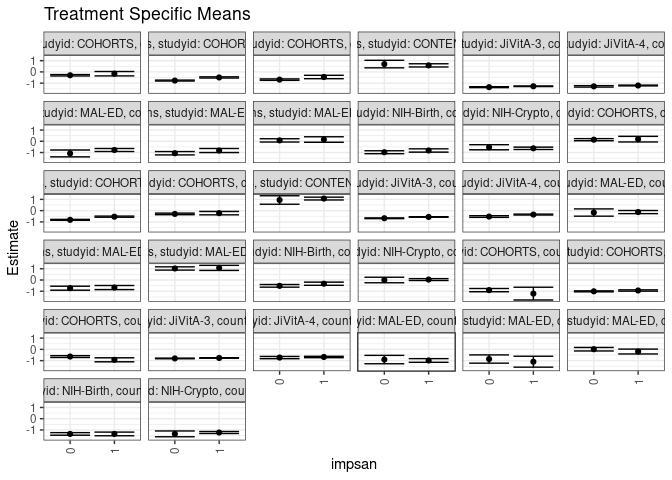

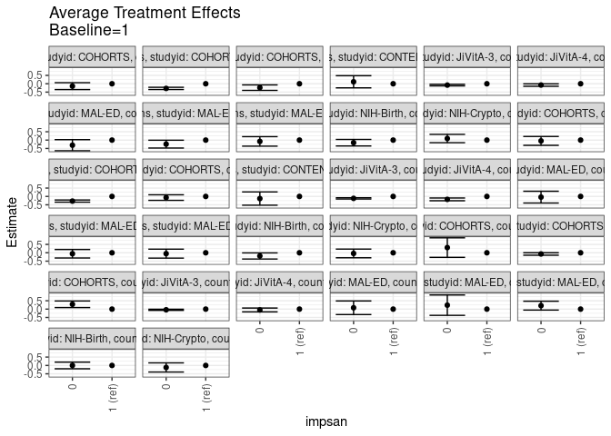

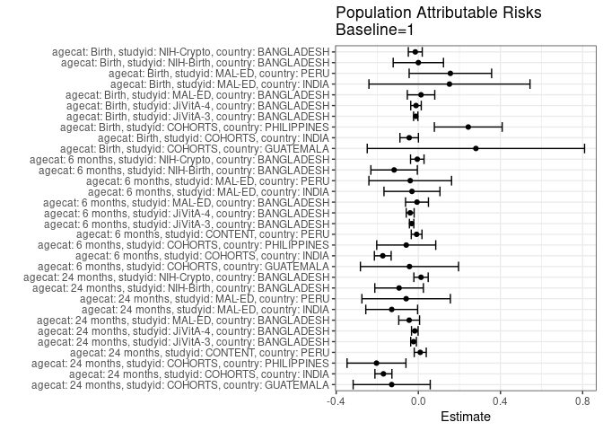

## Results Table

### Parameter: TSM

| agecat | studyid | country | intervention_level | baseline_level | estimate | ci_lower | ci_upper |
| --- | --- | --- | --- | --- | --- | --- | --- |
| Birth | COHORTS | GUATEMALA | 1 | NA | -1.2097674 | -1.7770248 | -0.6425100 |
| Birth | COHORTS | GUATEMALA | 0 | NA | -0.8997537 | -1.0430165 | -0.7564909 |
| Birth | COHORTS | INDIA | 1 | NA | -0.9326588 | -0.9904202 | -0.8748973 |
| Birth | COHORTS | INDIA | 0 | NA | -1.0041931 | -1.0477639 | -0.9606223 |
| Birth | COHORTS | PHILIPPINES | 1 | NA | -0.9272881 | -1.1054546 | -0.7491217 |
| Birth | COHORTS | PHILIPPINES | 0 | NA | -0.6387460 | -0.7199134 | -0.5575787 |
| Birth | JiVitA-3 | BANGLADESH | 1 | NA | -0.7651269 | -0.7877891 | -0.7424646 |
| Birth | JiVitA-3 | BANGLADESH | 0 | NA | -0.8058498 | -0.8345906 | -0.7771089 |
| Birth | JiVitA-4 | BANGLADESH | 1 | NA | -0.6769392 | -0.7371201 | -0.6167584 |
| Birth | JiVitA-4 | BANGLADESH | 0 | NA | -0.7275514 | -0.8267441 | -0.6283587 |
| Birth | MAL-ED | BANGLADESH | 1 | NA | -0.9860714 | -1.1483728 | -0.8237701 |
| Birth | MAL-ED | BANGLADESH | 0 | NA | -0.9054545 | -1.2780195 | -0.5328896 |
| Birth | MAL-ED | INDIA | 1 | NA | -1.0957143 | -1.5806679 | -0.6107607 |
| Birth | MAL-ED | INDIA | 0 | NA | -0.8592000 | -1.2277862 | -0.4906138 |
| Birth | MAL-ED | PERU | 1 | NA | -0.1942000 | -0.4103377 | 0.0219377 |
| Birth | MAL-ED | PERU | 0 | NA | 0.0128758 | -0.1419629 | 0.1677145 |
| Birth | NIH-Birth | BANGLADESH | 1 | NA | -1.3499775 | -1.5129665 | -1.1869884 |
| Birth | NIH-Birth | BANGLADESH | 0 | NA | -1.3498867 | -1.4648156 | -1.2349577 |
| Birth | NIH-Crypto | BANGLADESH | 1 | NA | -1.2254508 | -1.3148701 | -1.1360316 |
| Birth | NIH-Crypto | BANGLADESH | 0 | NA | -1.3454651 | -1.6035142 | -1.0874160 |
| 6 months | COHORTS | GUATEMALA | 1 | NA | 0.1889552 | -0.0603936 | 0.4383041 |
| 6 months | COHORTS | GUATEMALA | 0 | NA | 0.1409645 | 0.0484498 | 0.2334792 |
| 6 months | COHORTS | INDIA | 1 | NA | -0.5374029 | -0.5878113 | -0.4869945 |
| 6 months | COHORTS | INDIA | 0 | NA | -0.8159060 | -0.8574428 | -0.7743692 |
| 6 months | COHORTS | PHILIPPINES | 1 | NA | -0.2241958 | -0.3741126 | -0.0742790 |
| 6 months | COHORTS | PHILIPPINES | 0 | NA | -0.2919787 | -0.3621714 | -0.2217860 |
| 6 months | CONTENT | PERU | 1 | NA | 1.0727189 | 0.9498079 | 1.1956299 |
| 6 months | CONTENT | PERU | 0 | NA | 0.9453929 | 0.5695892 | 1.3211965 |
| 6 months | JiVitA-3 | BANGLADESH | 1 | NA | -0.5604582 | -0.5833363 | -0.5375801 |
| 6 months | JiVitA-3 | BANGLADESH | 0 | NA | -0.6756957 | -0.7081148 | -0.6432765 |
| 6 months | JiVitA-4 | BANGLADESH | 1 | NA | -0.3504794 | -0.3920046 | -0.3089541 |
| 6 months | JiVitA-4 | BANGLADESH | 0 | NA | -0.5257182 | -0.5991376 | -0.4522988 |
| 6 months | MAL-ED | BANGLADESH | 1 | NA | -0.1267987 | -0.2675787 | 0.0139814 |
| 6 months | MAL-ED | BANGLADESH | 0 | NA | -0.1680702 | -0.4906416 | 0.1545012 |
| 6 months | MAL-ED | INDIA | 1 | NA | -0.6708642 | -0.8524306 | -0.4892978 |
| 6 months | MAL-ED | INDIA | 0 | NA | -0.7285400 | -0.9061236 | -0.5509564 |
| 6 months | MAL-ED | PERU | 1 | NA | 1.0767179 | 0.8529374 | 1.3004985 |
| 6 months | MAL-ED | PERU | 0 | NA | 1.0243561 | 0.8781934 | 1.1705187 |
| 6 months | NIH-Birth | BANGLADESH | 1 | NA | -0.3295000 | -0.4693880 | -0.1896120 |
| 6 months | NIH-Birth | BANGLADESH | 0 | NA | -0.5202058 | -0.6375273 | -0.4028844 |
| 6 months | NIH-Crypto | BANGLADESH | 1 | NA | 0.0387398 | -0.0450978 | 0.1225775 |
| 6 months | NIH-Crypto | BANGLADESH | 0 | NA | -0.0012921 | -0.2470796 | 0.2444953 |
| 24 months | COHORTS | GUATEMALA | 1 | NA | -0.1564935 | -0.3517559 | 0.0387688 |
| 24 months | COHORTS | GUATEMALA | 0 | NA | -0.2982809 | -0.3611991 | -0.2353627 |
| 24 months | COHORTS | INDIA | 1 | NA | -0.4907687 | -0.5439126 | -0.4376248 |
| 24 months | COHORTS | INDIA | 0 | NA | -0.7698941 | -0.8116988 | -0.7280895 |
| 24 months | COHORTS | PHILIPPINES | 1 | NA | -0.4527419 | -0.6040816 | -0.3014023 |
| 24 months | COHORTS | PHILIPPINES | 0 | NA | -0.6854776 | -0.7479453 | -0.6230098 |
| 24 months | CONTENT | PERU | 1 | NA | 0.5809272 | 0.4381190 | 0.7237353 |
| 24 months | CONTENT | PERU | 0 | NA | 0.6984615 | 0.3635612 | 1.0333619 |
| 24 months | JiVitA-3 | BANGLADESH | 1 | NA | -1.2737666 | -1.3012095 | -1.2463238 |
| 24 months | JiVitA-3 | BANGLADESH | 0 | NA | -1.3535128 | -1.3936262 | -1.3133993 |
| 24 months | JiVitA-4 | BANGLADESH | 1 | NA | -1.2060120 | -1.2413492 | -1.1706748 |
| 24 months | JiVitA-4 | BANGLADESH | 0 | NA | -1.2826818 | -1.3465837 | -1.2187799 |
| 24 months | MAL-ED | BANGLADESH | 1 | NA | -0.7747238 | -0.9066216 | -0.6428259 |
| 24 months | MAL-ED | BANGLADESH | 0 | NA | -1.0795161 | -1.3842300 | -0.7748023 |
| 24 months | MAL-ED | INDIA | 1 | NA | -0.8194231 | -0.9988466 | -0.6399996 |
| 24 months | MAL-ED | INDIA | 0 | NA | -1.0604132 | -1.2087690 | -0.9120575 |
| 24 months | MAL-ED | PERU | 1 | NA | 0.1565603 | -0.0871381 | 0.4002587 |
| 24 months | MAL-ED | PERU | 0 | NA | 0.0785291 | -0.0657249 | 0.2227830 |
| 24 months | NIH-Birth | BANGLADESH | 1 | NA | -0.8179853 | -0.9643157 | -0.6716549 |
| 24 months | NIH-Birth | BANGLADESH | 0 | NA | -0.9732494 | -1.1034383 | -0.8430604 |
| 24 months | NIH-Crypto | BANGLADESH | 1 | NA | -0.6247113 | -0.7300064 | -0.5194162 |
| 24 months | NIH-Crypto | BANGLADESH | 0 | NA | -0.5302857 | -0.7567763 | -0.3037952 |

### Parameter: E(Y)

| agecat | studyid | country | intervention_level | baseline_level | estimate | ci_lower | ci_upper |
| --- | --- | --- | --- | --- | --- | --- | --- |
| Birth | COHORTS | GUATEMALA | NA | NA | -0.9294432 | -1.0701697 | -0.7887168 |
| Birth | COHORTS | INDIA | NA | NA | -0.9771733 | -1.0119896 | -0.9423570 |
| Birth | COHORTS | PHILIPPINES | NA | NA | -0.6841030 | -0.7582767 | -0.6099293 |
| Birth | JiVitA-3 | BANGLADESH | NA | NA | -0.7777528 | -0.7967725 | -0.7587330 |
| Birth | JiVitA-4 | BANGLADESH | NA | NA | -0.6882498 | -0.7406539 | -0.6358456 |
| Birth | MAL-ED | BANGLADESH | NA | NA | -0.9728358 | -1.1217009 | -0.8239707 |
| Birth | MAL-ED | INDIA | NA | NA | -0.9441026 | -1.2397919 | -0.6484132 |
| Birth | MAL-ED | PERU | NA | NA | -0.0381281 | -0.1669868 | 0.0907307 |
| Birth | NIH-Birth | BANGLADESH | NA | NA | -1.3499217 | -1.4444634 | -1.2553801 |
| Birth | NIH-Crypto | BANGLADESH | NA | NA | -1.2402802 | -1.3249395 | -1.1556208 |
| 6 months | COHORTS | GUATEMALA | NA | NA | 0.1458511 | 0.0589571 | 0.2327450 |
| 6 months | COHORTS | INDIA | NA | NA | -0.7104855 | -0.7428053 | -0.6781657 |
| 6 months | COHORTS | PHILIPPINES | NA | NA | -0.2830286 | -0.3471028 | -0.2189545 |
| 6 months | CONTENT | PERU | NA | NA | 1.0644279 | 0.9468682 | 1.1819876 |
| 6 months | JiVitA-3 | BANGLADESH | NA | NA | -0.5931476 | -0.6127125 | -0.5735828 |
| 6 months | JiVitA-4 | BANGLADESH | NA | NA | -0.3901595 | -0.4274150 | -0.3529041 |
| 6 months | MAL-ED | BANGLADESH | NA | NA | -0.1333333 | -0.2623761 | -0.0042906 |
| 6 months | MAL-ED | INDIA | NA | NA | -0.7018062 | -0.8289790 | -0.5746333 |
| 6 months | MAL-ED | PERU | NA | NA | 1.0372972 | 0.9141109 | 1.1604836 |
| 6 months | NIH-Birth | BANGLADESH | NA | NA | -0.4474038 | -0.5378167 | -0.3569909 |
| 6 months | NIH-Crypto | BANGLADESH | NA | NA | 0.0336790 | -0.0458848 | 0.1132428 |
| 24 months | COHORTS | GUATEMALA | NA | NA | -0.2861905 | -0.3461594 | -0.2262216 |
| 24 months | COHORTS | INDIA | NA | NA | -0.6606874 | -0.6938402 | -0.6275347 |
| 24 months | COHORTS | PHILIPPINES | NA | NA | -0.6564149 | -0.7144543 | -0.5983756 |
| 24 months | CONTENT | PERU | NA | NA | 0.5902439 | 0.4560143 | 0.7244735 |
| 24 months | JiVitA-3 | BANGLADESH | NA | NA | -1.2970418 | -1.3203361 | -1.2737475 |
| 24 months | JiVitA-4 | BANGLADESH | NA | NA | -1.2231776 | -1.2550332 | -1.1913220 |
| 24 months | MAL-ED | BANGLADESH | NA | NA | -0.8192925 | -0.9412667 | -0.6973182 |
| 24 months | MAL-ED | INDIA | NA | NA | -0.9490222 | -1.0651720 | -0.8328724 |
| 24 months | MAL-ED | PERU | NA | NA | 0.0972406 | -0.0271085 | 0.2215898 |
| 24 months | NIH-Birth | BANGLADESH | NA | NA | -0.9115790 | -1.0095022 | -0.8136559 |
| 24 months | NIH-Crypto | BANGLADESH | NA | NA | -0.6115706 | -0.7075788 | -0.5155624 |

### Parameter: ATE

| agecat | studyid | country | intervention_level | baseline_level | estimate | ci_lower | ci_upper |
| --- | --- | --- | --- | --- | --- | --- | --- |
| Birth | COHORTS | GUATEMALA | 1 | 1 | 0.0000000 | 0.0000000 | 0.0000000 |
| Birth | COHORTS | GUATEMALA | 0 | 1 | 0.3100137 | -0.2750548 | 0.8950823 |
| Birth | COHORTS | INDIA | 1 | 1 | 0.0000000 | 0.0000000 | 0.0000000 |
| Birth | COHORTS | INDIA | 0 | 1 | -0.0715343 | -0.1438862 | 0.0008176 |
| Birth | COHORTS | PHILIPPINES | 1 | 1 | 0.0000000 | 0.0000000 | 0.0000000 |
| Birth | COHORTS | PHILIPPINES | 0 | 1 | 0.2885421 | 0.0927580 | 0.4843262 |
| Birth | JiVitA-3 | BANGLADESH | 1 | 1 | 0.0000000 | 0.0000000 | 0.0000000 |
| Birth | JiVitA-3 | BANGLADESH | 0 | 1 | -0.0407229 | -0.0747974 | -0.0066483 |
| Birth | JiVitA-4 | BANGLADESH | 1 | 1 | 0.0000000 | 0.0000000 | 0.0000000 |
| Birth | JiVitA-4 | BANGLADESH | 0 | 1 | -0.0506122 | -0.1651007 | 0.0638763 |
| Birth | MAL-ED | BANGLADESH | 1 | 1 | 0.0000000 | 0.0000000 | 0.0000000 |
| Birth | MAL-ED | BANGLADESH | 0 | 1 | 0.0806169 | -0.3257652 | 0.4869990 |
| Birth | MAL-ED | INDIA | 1 | 1 | 0.0000000 | 0.0000000 | 0.0000000 |
| Birth | MAL-ED | INDIA | 0 | 1 | 0.2365143 | -0.3726128 | 0.8456413 |
| Birth | MAL-ED | PERU | 1 | 1 | 0.0000000 | 0.0000000 | 0.0000000 |
| Birth | MAL-ED | PERU | 0 | 1 | 0.2070758 | -0.0588010 | 0.4729527 |
| Birth | NIH-Birth | BANGLADESH | 1 | 1 | 0.0000000 | 0.0000000 | 0.0000000 |
| Birth | NIH-Birth | BANGLADESH | 0 | 1 | 0.0000908 | -0.1993436 | 0.1995252 |
| Birth | NIH-Crypto | BANGLADESH | 1 | 1 | 0.0000000 | 0.0000000 | 0.0000000 |
| Birth | NIH-Crypto | BANGLADESH | 0 | 1 | -0.1200143 | -0.3931171 | 0.1530885 |
| 6 months | COHORTS | GUATEMALA | 1 | 1 | 0.0000000 | 0.0000000 | 0.0000000 |
| 6 months | COHORTS | GUATEMALA | 0 | 1 | -0.0479908 | -0.3139491 | 0.2179675 |
| 6 months | COHORTS | INDIA | 1 | 1 | 0.0000000 | 0.0000000 | 0.0000000 |
| 6 months | COHORTS | INDIA | 0 | 1 | -0.2785031 | -0.3438202 | -0.2131861 |
| 6 months | COHORTS | PHILIPPINES | 1 | 1 | 0.0000000 | 0.0000000 | 0.0000000 |
| 6 months | COHORTS | PHILIPPINES | 0 | 1 | -0.0677829 | -0.2333186 | 0.0977527 |
| 6 months | CONTENT | PERU | 1 | 1 | 0.0000000 | 0.0000000 | 0.0000000 |
| 6 months | CONTENT | PERU | 0 | 1 | -0.1273260 | -0.5227189 | 0.2680668 |
| 6 months | JiVitA-3 | BANGLADESH | 1 | 1 | 0.0000000 | 0.0000000 | 0.0000000 |
| 6 months | JiVitA-3 | BANGLADESH | 0 | 1 | -0.1152375 | -0.1530712 | -0.0774038 |
| 6 months | JiVitA-4 | BANGLADESH | 1 | 1 | 0.0000000 | 0.0000000 | 0.0000000 |
| 6 months | JiVitA-4 | BANGLADESH | 0 | 1 | -0.1752388 | -0.2581557 | -0.0923219 |
| 6 months | MAL-ED | BANGLADESH | 1 | 1 | 0.0000000 | 0.0000000 | 0.0000000 |
| 6 months | MAL-ED | BANGLADESH | 0 | 1 | -0.0412715 | -0.3932251 | 0.3106821 |
| 6 months | MAL-ED | INDIA | 1 | 1 | 0.0000000 | 0.0000000 | 0.0000000 |
| 6 months | MAL-ED | INDIA | 0 | 1 | -0.0576758 | -0.3116488 | 0.1962972 |
| 6 months | MAL-ED | PERU | 1 | 1 | 0.0000000 | 0.0000000 | 0.0000000 |
| 6 months | MAL-ED | PERU | 0 | 1 | -0.0523619 | -0.3196468 | 0.2149231 |
| 6 months | NIH-Birth | BANGLADESH | 1 | 1 | 0.0000000 | 0.0000000 | 0.0000000 |
| 6 months | NIH-Birth | BANGLADESH | 0 | 1 | -0.1907058 | -0.3732790 | -0.0081326 |
| 6 months | NIH-Crypto | BANGLADESH | 1 | 1 | 0.0000000 | 0.0000000 | 0.0000000 |
| 6 months | NIH-Crypto | BANGLADESH | 0 | 1 | -0.0400320 | -0.2997245 | 0.2196606 |
| 24 months | COHORTS | GUATEMALA | 1 | 1 | 0.0000000 | 0.0000000 | 0.0000000 |
| 24 months | COHORTS | GUATEMALA | 0 | 1 | -0.1417874 | -0.3469363 | 0.0633616 |
| 24 months | COHORTS | INDIA | 1 | 1 | 0.0000000 | 0.0000000 | 0.0000000 |
| 24 months | COHORTS | INDIA | 0 | 1 | -0.2791254 | -0.3467413 | -0.2115096 |
| 24 months | COHORTS | PHILIPPINES | 1 | 1 | 0.0000000 | 0.0000000 | 0.0000000 |
| 24 months | COHORTS | PHILIPPINES | 0 | 1 | -0.2327356 | -0.3964607 | -0.0690105 |
| 24 months | CONTENT | PERU | 1 | 1 | 0.0000000 | 0.0000000 | 0.0000000 |
| 24 months | CONTENT | PERU | 0 | 1 | 0.1175344 | -0.2465431 | 0.4816118 |
| 24 months | JiVitA-3 | BANGLADESH | 1 | 1 | 0.0000000 | 0.0000000 | 0.0000000 |
| 24 months | JiVitA-3 | BANGLADESH | 0 | 1 | -0.0797461 | -0.1269963 | -0.0324959 |
| 24 months | JiVitA-4 | BANGLADESH | 1 | 1 | 0.0000000 | 0.0000000 | 0.0000000 |
| 24 months | JiVitA-4 | BANGLADESH | 0 | 1 | -0.0766698 | -0.1479056 | -0.0054340 |
| 24 months | MAL-ED | BANGLADESH | 1 | 1 | 0.0000000 | 0.0000000 | 0.0000000 |
| 24 months | MAL-ED | BANGLADESH | 0 | 1 | -0.3047924 | -0.6368279 | 0.0272431 |
| 24 months | MAL-ED | INDIA | 1 | 1 | 0.0000000 | 0.0000000 | 0.0000000 |
| 24 months | MAL-ED | INDIA | 0 | 1 | -0.2409901 | -0.4738038 | -0.0081765 |
| 24 months | MAL-ED | PERU | 1 | 1 | 0.0000000 | 0.0000000 | 0.0000000 |
| 24 months | MAL-ED | PERU | 0 | 1 | -0.0780312 | -0.3612239 | 0.2051615 |
| 24 months | NIH-Birth | BANGLADESH | 1 | 1 | 0.0000000 | 0.0000000 | 0.0000000 |
| 24 months | NIH-Birth | BANGLADESH | 0 | 1 | -0.1552641 | -0.3511256 | 0.0405975 |
| 24 months | NIH-Crypto | BANGLADESH | 1 | 1 | 0.0000000 | 0.0000000 | 0.0000000 |
| 24 months | NIH-Crypto | BANGLADESH | 0 | 1 | 0.0944256 | -0.1553443 | 0.3441955 |

### Parameter: PAR

| agecat | studyid | country | intervention_level | baseline_level | estimate | ci_lower | ci_upper |
| --- | --- | --- | --- | --- | --- | --- | --- |
| Birth | COHORTS | GUATEMALA | 1 | NA | 0.2803242 | -0.2487807 | 0.8094292 |
| Birth | COHORTS | INDIA | 1 | NA | -0.0445145 | -0.0895493 | 0.0005203 |
| Birth | COHORTS | PHILIPPINES | 1 | NA | 0.2431851 | 0.0780629 | 0.4083073 |
| Birth | JiVitA-3 | BANGLADESH | 1 | NA | -0.0126259 | -0.0231835 | -0.0020682 |
| Birth | JiVitA-4 | BANGLADESH | 1 | NA | -0.0113106 | -0.0369274 | 0.0143062 |
| Birth | MAL-ED | BANGLADESH | 1 | NA | 0.0132356 | -0.0536121 | 0.0800833 |
| Birth | MAL-ED | INDIA | 1 | NA | 0.1516117 | -0.2405171 | 0.5437405 |
| Birth | MAL-ED | PERU | 1 | NA | 0.1560719 | -0.0446954 | 0.3568392 |
| Birth | NIH-Birth | BANGLADESH | 1 | NA | 0.0000557 | -0.1223797 | 0.1224911 |
| Birth | NIH-Crypto | BANGLADESH | 1 | NA | -0.0148294 | -0.0487023 | 0.0190436 |
| 6 months | COHORTS | GUATEMALA | 1 | NA | -0.0431042 | -0.2819842 | 0.1957759 |
| 6 months | COHORTS | INDIA | 1 | NA | -0.1730826 | -0.2138491 | -0.1323162 |
| 6 months | COHORTS | PHILIPPINES | 1 | NA | -0.0588328 | -0.2025175 | 0.0848519 |
| 6 months | CONTENT | PERU | 1 | NA | -0.0082910 | -0.0343793 | 0.0177973 |
| 6 months | JiVitA-3 | BANGLADESH | 1 | NA | -0.0326894 | -0.0434290 | -0.0219498 |
| 6 months | JiVitA-4 | BANGLADESH | 1 | NA | -0.0396801 | -0.0589327 | -0.0204276 |
| 6 months | MAL-ED | BANGLADESH | 1 | NA | -0.0065347 | -0.0622934 | 0.0492241 |
| 6 months | MAL-ED | INDIA | 1 | NA | -0.0309420 | -0.1672438 | 0.1053599 |
| 6 months | MAL-ED | PERU | 1 | NA | -0.0394207 | -0.2406652 | 0.1618238 |
| 6 months | NIH-Birth | BANGLADESH | 1 | NA | -0.1179038 | -0.2310518 | -0.0047558 |
| 6 months | NIH-Crypto | BANGLADESH | 1 | NA | -0.0050609 | -0.0379060 | 0.0277843 |
| 24 months | COHORTS | GUATEMALA | 1 | NA | -0.1296970 | -0.3173704 | 0.0579764 |
| 24 months | COHORTS | INDIA | 1 | NA | -0.1699187 | -0.2113121 | -0.1285254 |
| 24 months | COHORTS | PHILIPPINES | 1 | NA | -0.2036730 | -0.3470330 | -0.0603129 |
| 24 months | CONTENT | PERU | 1 | NA | 0.0093168 | -0.0199518 | 0.0385853 |
| 24 months | JiVitA-3 | BANGLADESH | 1 | NA | -0.0232751 | -0.0370636 | -0.0094867 |
| 24 months | JiVitA-4 | BANGLADESH | 1 | NA | -0.0171656 | -0.0331862 | -0.0011450 |
| 24 months | MAL-ED | BANGLADESH | 1 | NA | -0.0445687 | -0.0952489 | 0.0061115 |
| 24 months | MAL-ED | INDIA | 1 | NA | -0.1295991 | -0.2557860 | -0.0034123 |
| 24 months | MAL-ED | PERU | 1 | NA | -0.0593196 | -0.2746547 | 0.1560154 |
| 24 months | NIH-Birth | BANGLADESH | 1 | NA | -0.0935938 | -0.2118795 | 0.0246920 |
| 24 months | NIH-Crypto | BANGLADESH | 1 | NA | 0.0131407 | -0.0217359 | 0.0480174 |